# Segmentation of Prosper Borrowers

## Investigation Overview

The following analysis looks into a couple of variables which segment borrowers into groups which can expect to receive different interest rates and loan amounts.

## Dataset Overview

The loans dataset contains 113k+ Prosper loans from the period 2005-2014 and 81 variables. Prosper is a US peer-to-peer landing company founded in 2005, so the dataset covers the first years of their business. The data collection went through changes in 2009, which we kept in mind during the investigation.

## Credit rating

Credit rating was engineered by merging of two columns: CreditGrade, which was used before 2009 and ProsperRating, which is in use since 2009. This allows us to work with the whole dataset. Credit risk was further engineered from the credit rating by dividing ratings into 3 categories:

- AA, A ratings are considered low risk,
- B, C, D ratings are considered medium risk,
- E, HR, NC ratings are considered high risk.

```
Text(0,0.5,'Number of loans')
```

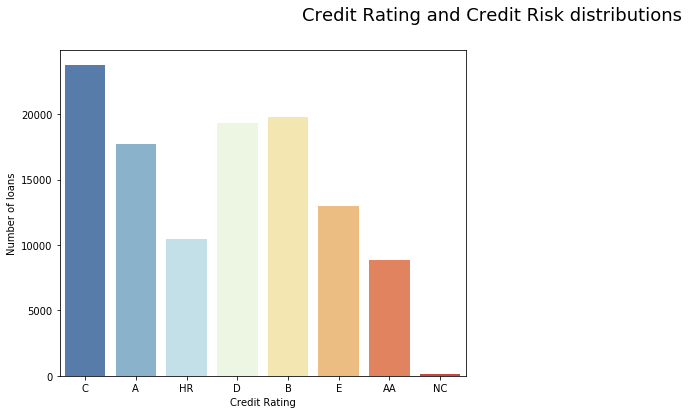

```python
plt.figure(figsize=(16,6))
plt.suptitle("Credit Rating and Credit Risk distributions", size = 18)
plt.subplot(1,2,1)
sns.countplot(data = df, x = 'CreditRating', palette = 'RdYlBu_r')
plt.xlabel('Credit Rating')
plt.ylabel('Number of loans')
```

[output not shown]

## Interest Rate

- We use the borrower annual percentage rate (APR) as the interest rate measure.
- The most frequent rates are also in the high end of 0.35 - 0.37.
- The average interest rate was increasing steeply between 2007-2011, but it is decreasing since then.

```
Text(0.5,0,'Loan origination year')
```

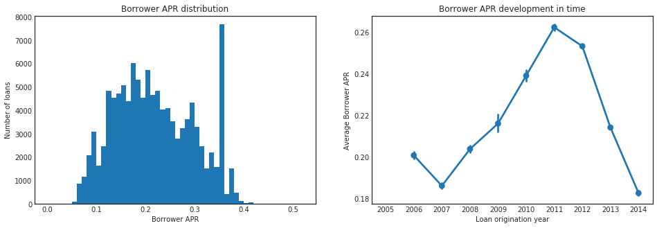

```python
df["LoanOriginationDate"] = pd.to_datetime(df["LoanOriginationDate"])
sns.set_style("white")
plt.figure(figsize=(16,5))

plt.subplot(1,2,1)
bins = np.arange(0, df["BorrowerAPR"].max()+0.01, 0.01)
plt.hist(data = df.dropna(subset=["BorrowerAPR"]), x = 'BorrowerAPR', bins = bins)
plt.title('Borrower APR distribution')
plt.xlabel('Borrower APR')
plt.ylabel('Number of loans')

plt.subplot(1,2,2)
sns.pointplot(data = df, x = df['LoanOriginationDate'].dt.year, y = 'BorrowerAPR')
plt.title('Borrower APR development in time')
plt.ylabel('Average Borrower APR')
plt.xlabel('Loan origination year')
```

## Loan original Amount

- Distribution of loan amount is multimodal, with the most popular loan amounts being 4k, 15k and 10k.
- The average loan amount is increasing each year since 2010.

```
(0, 14000)
```

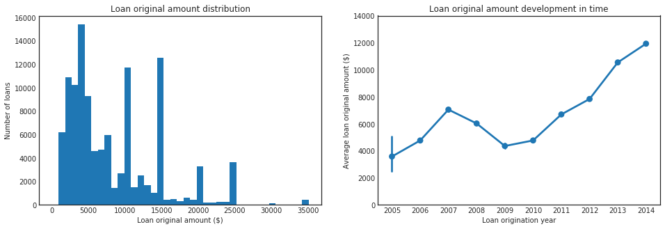

```python
sns.set_style("white")
plt.figure(figsize=(16,5))
plt.subplot(1,2,1)
bins = np.arange(0, df['LoanOriginalAmount'].max()+900, 900)
plt.hist(data = df, x = 'LoanOriginalAmount', bins = bins)
plt.title('Loan original amount distribution')
plt.xlabel('Loan original amount ($)')
plt.ylabel('Number of loans')


plt.subplot(1,2,2)
sns.pointplot(data = df, x = df['LoanOriginationDate'].dt.year, y = 'LoanOriginalAmount')
plt.title('Loan original amount development in time')
plt.ylabel('Average loan original amount ($)')
plt.xlabel('Loan origination year')
plt.ylim((0,14000))
```

## Monthly Loan Payment

The most frequent monthly payments are between USD 172 - 175.

Monthly payment has a strong relationship with the loan amount. It makes sense that when someone borrows more, they also generally need to pay higher monthly payments, which can be mitigated only by borrowing for a longer period of time. For this reason, we will focus only on the loan amount in further analysis.

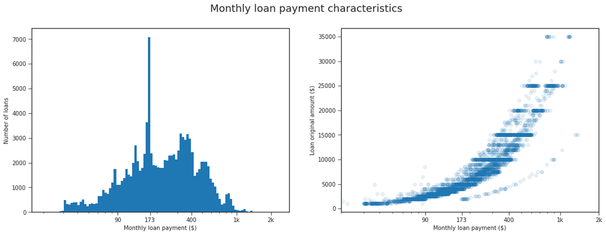

```python
sns.set_style("ticks")
# a sample of 5000 from the data
sample = np.random.choice(df.shape[0], 5000, replace = False)
df_samp = df.iloc[sample,:]

plt.figure(figsize=[18, 6])
plt.suptitle('Monthly loan payment characteristics', size = 18)
plt.subplot(1,2,1)
log_binsize = 0.02
bins = 10 ** np.arange(1.3, np.log10(df['MonthlyLoanPayment'].max())+log_binsize, log_binsize)
plt.hist(data = df, x = 'MonthlyLoanPayment', bins = bins)
plt.xscale('log')
plt.xlabel('Monthly loan payment ($)')
plt.ylabel('Number of loans')
plt.xticks([90, 173, 400, 1e3, 2e3], [90, 173, 400, '1k', '2k'])


plt.subplot(1,2,2)
plt.scatter(data = df_samp, x = 'MonthlyLoanPayment', y = 'LoanOriginalAmount', alpha = 1/10)
plt.ylabel('Loan original amount ($)')
plt.xlabel('Monthly loan payment ($)')
plt.xlim((20,2000))
plt.xscale('log')
plt.xticks([90, 173, 400, 1e3, 2e3], [90, 173, 400, '1k', '2k'])


plt.show();
```

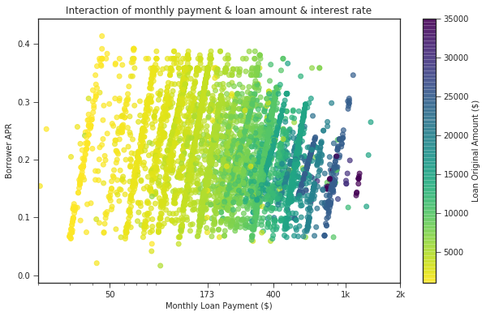

```python
plt.figure(figsize=[10, 6])
plt.scatter(data = df_samp, x = 'MonthlyLoanPayment', y = 'BorrowerAPR', alpha = 0.7, c = 'LoanOriginalAmount', \
            cmap = 'viridis_r')
plt.colorbar(label = 'Loan Original Amount ($)')
plt.ylabel('Borrower APR')
plt.xlabel('Monthly Loan Payment ($)')
plt.title('Interaction of monthly payment & loan amount & interest rate')
plt.xlim((20,2000))
plt.xscale('log')
plt.xticks([50, 173, 400, 1e3, 2e3], [50, 173, 400, '1k', '2k'])

plt.show()
```